# Exploração do clima em João Pessoa, Campina Grande e Patos - PB

Matheus Gomes Maia

# Atividade L1P1 - FPCC2

# Aluno: Matheus Gomes Maia

```r
library(tidyverse)
library(here)
theme_set(theme_bw())
```

Nesse exercício vamos fazer um relatório respondendo algumas perguntas sobre os dados climáticos das cidades de João Pessoa, Campina Grande e Patos.

Leitura dos dados:

```r
# SEMPRE read_csv NUNCA read.csv
clima_tudo = read_csv(
    here("data/tempo-jp-cg-pt.csv"),
    col_types = cols(
        .default = col_double(),
        cidade = col_character(),
        semana = col_date(format = ""),
        ano = col_integer(),
        mes = col_integer()
    )
)

clima2019 = clima_tudo %>%
    filter(ano == 2019)

clima2019 %>%
    slice(1:8)
```

```
## # A tibble: 8 x 11
##   cidade   semana     temp_max temp_media temp_min vento_medio vento_max umidade
##   <chr>    <date>        <dbl>      <dbl>    <dbl>       <dbl>     <dbl>   <dbl>
## 1 Campina… 2019-01-06     32.1       25.6     19.6        3.57       4.6    74.9
## 2 Campina… 2019-01-13     33.5       27.1     20          3.29       4.5    69
## 3 Campina… 2019-01-20     33.3       26.7     19.6        4.01       6.5    72.5
## 4 Campina… 2019-01-27     32.4       26.4     19.6        3.53       5      75.0
## 5 Campina… 2019-02-03     32.2       25.3     19.5        2.95       4.8    83
## 6 Campina… 2019-02-10     31.1       25.6     20.1        3.17       5      84.1
## 7 Campina… 2019-02-17     31.6       25.9     20.5        2.89       4.1    79.2
## 8 Campina… 2019-02-24     31.1       25.9     20.5        3.63       4.8    76.8
## # … with 3 more variables: chuva <dbl>, ano <int>, mes <int>
```

## 1. Análise dos Ventos

Vamos analisar os ventos nas três cidades no ano de 2019:

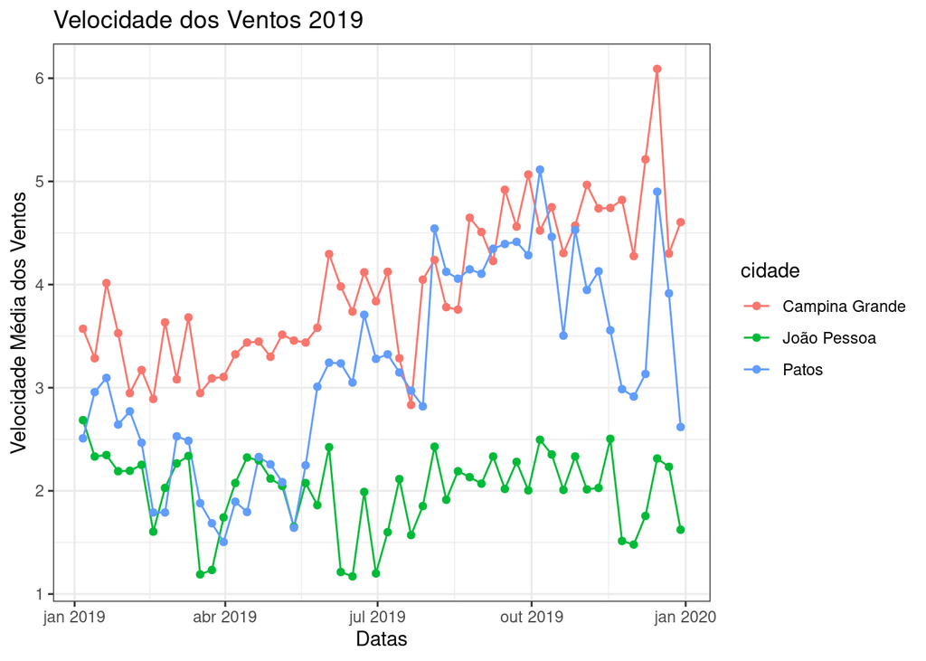

```r
ggplot(clima_tudo %>% filter(ano == 2019) , aes(x = semana, y = vento_medio, color = cidade)) +
  geom_line()+
  geom_point() +
  ggtitle("Velocidade dos Ventos 2019")+
  labs(
         x = "Datas",
         y = "Velocidade Média dos Ventos"
    )
```

Os picos e vales se alinham em muitas semanas, o que indica que a velocidade média dos ventos nas três cidades está correlacionada em parte do tempo. Campina Grande foi a cidade com ventos mais fortes em 2019. Patos venta como em João Pessoa no começo do ano e como Campina Grande no fim do ano.

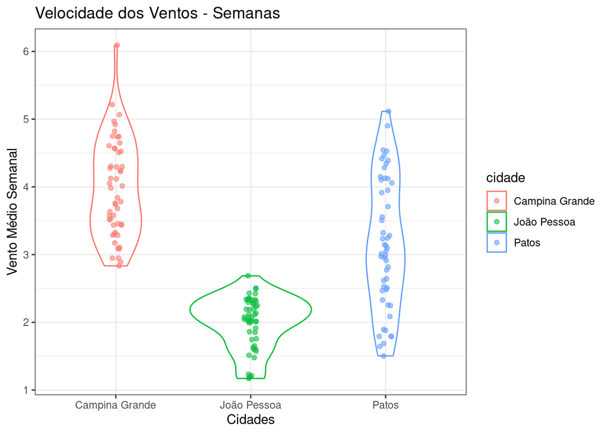

```r
ggplot(clima_tudo %>% filter(ano == 2019) , aes(x = cidade, y = vento_medio, color = cidade)) +
    geom_jitter(width = 0.05, alpha = .6) +
    geom_violin(alpha = 0.05)+
    ggtitle("Velocidade dos Ventos - Semanas ")+
    labs(
         x = "Cidades",
         y = "Vento Médio Semanal"
    )
```

João Pessoa possui uma concentração grande de medidas, enquanto que Patos e Campina Grande têm medidas mais espalhadas.

## 2. Análise Calor no Verão

Vamos analisar os meses mais quentes entre janeiro e marco nas três cidades.

```r
verao = clima_tudo %>% filter(mes < 4)  %>%
  filter(semana > "2018-04-10") %>% group_by(mes, ano, cidade) %>%
  summarise(mean = median(temp_media),
            max = ifelse(any(is.na(temp_max)), temp_media, max(temp_max)),
            min = ifelse(any(is.na(temp_min)), temp_media, min(temp_min)))
```

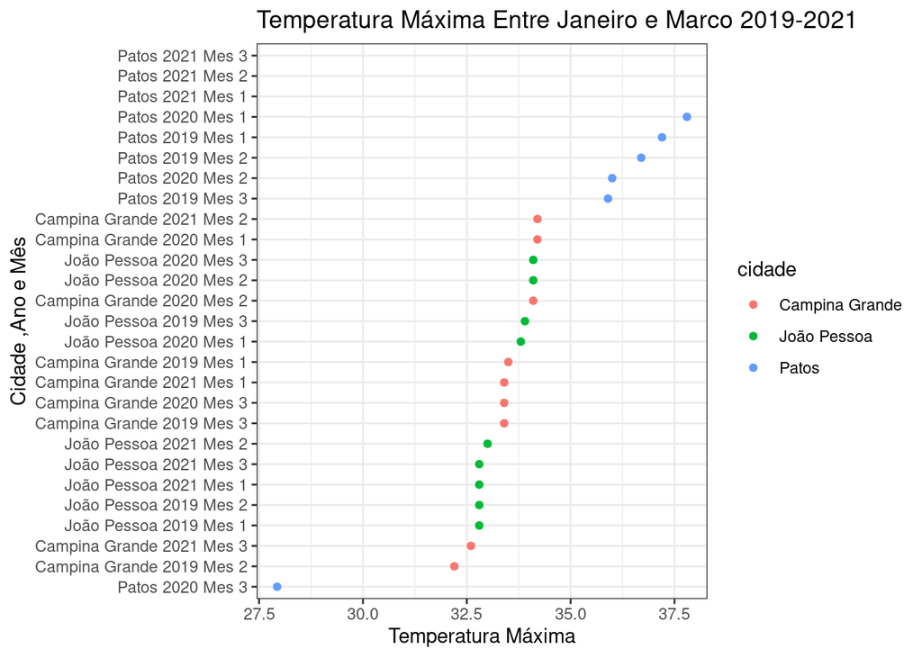

```r
verao$Concat = paste(verao$cidade, verao$ano, "Mes", verao$mes )
ggplot(verao,  aes(x = max, y = reorder(Concat, max), color = cidade)) +
  geom_point()+
  ggtitle("Temperatura Máxima Entre Janeiro e Marco 2019-2021 ")+
  labs(
       x = "Temperatura Máxima",
       y = "Cidade ,Ano e Mês"
  )
```

Apesar de existiream dados faltantes para Patos nos ano de 2020 e 2021 é perceptível que os meses mais quentes são sempre em Patos. Em média, Campina Grande é sempre mais fria que Patos e João Pessoa, mas existem semanas em que Campina Grande é mais quente que João Pessoa. Segundo os dados, Março de 2020 foi bastate frio em Patos. Possívelmente um erro nos dados.

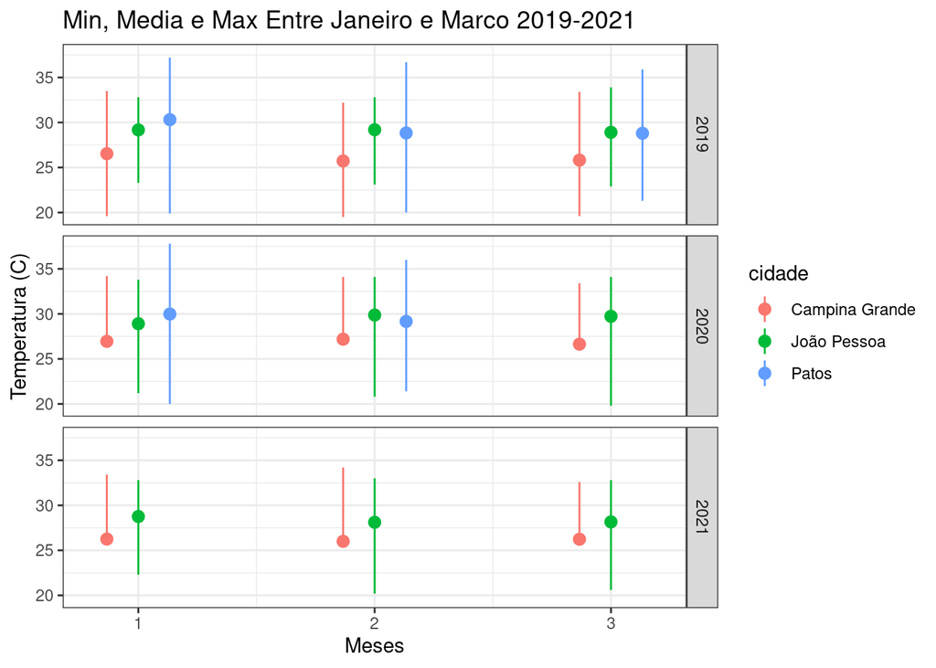

```r
ggplot(verao, aes(x = mes, y = mean, color = cidade, ymin=min, ymax=max)) +
  geom_pointrange(position=position_dodge(width=0.40))  +
  scale_x_continuous(breaks= scales::pretty_breaks(n = 3))+
  ylab("Temperatura") +
  facet_grid(rows = vars(ano))+
  ggtitle("Min, Media e Max Entre Janeiro e Marco 2019-2021")+
  labs(
       x = "Meses",
       y = "Temperatura (C)"
  )
```

Existem dados de temperatura mínima faltantes para Campina Grande nos anos de 2020 e 2021. A amplitude térmica em Patos aparenta ser a maior.

## 3. Análise dos meses de Junho

Como é a temperatura nas três cidades no período Junino?

```r
junho = clima_tudo %>% filter(mes == 6)%>%
  group_by(mes, ano, cidade) %>%
  summarise(mean = mean(temp_media), max = max(temp_max), min = min(temp_min))
```

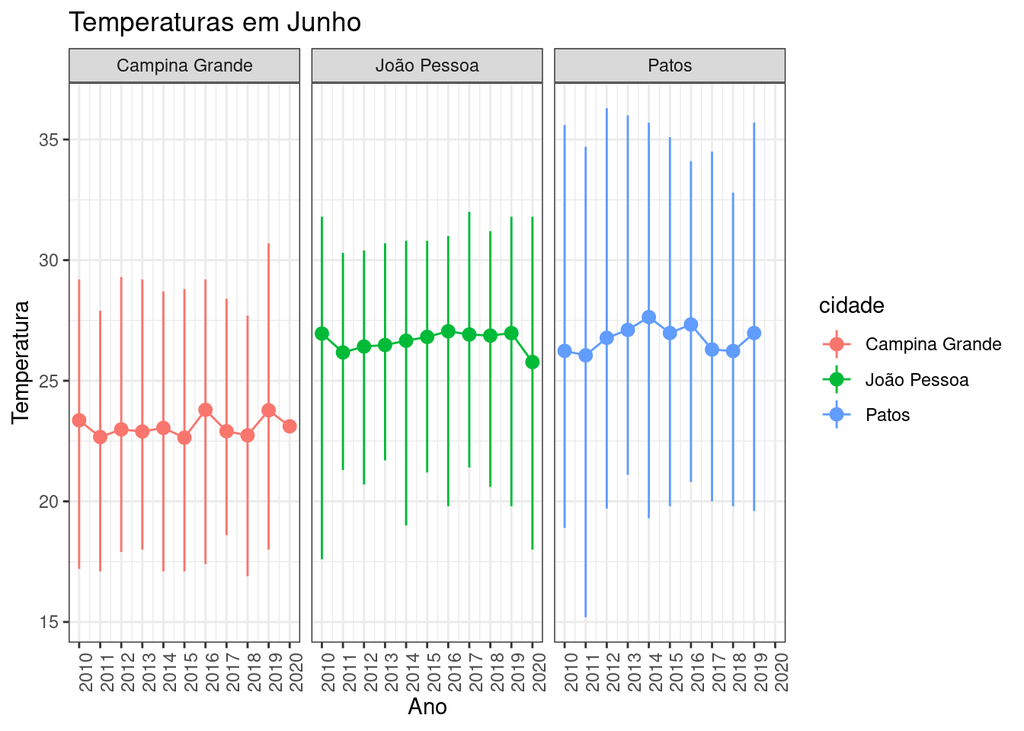

```r
ggplot(junho, aes(x = ano, y = mean, color = cidade, ymin=min, ymax=max)) +
  geom_line()+
  geom_pointrange()+
  scale_x_continuous(breaks= scales::pretty_breaks(n = 15))+
  facet_grid(cols = vars(cidade))+
  ggtitle("Temperaturas em Junho")+
  labs(
       x = "Ano",
       y = "Temperatura"
  )+ theme(axis.text.x=element_text(angle=90, hjust=1))
```

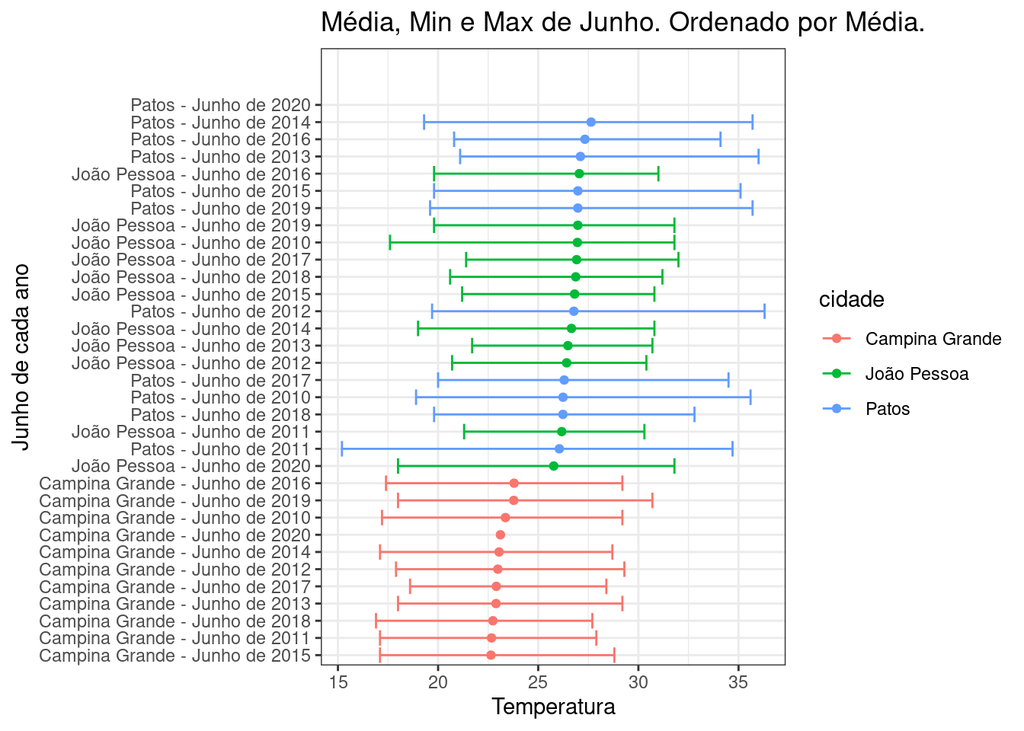

```r
junho$Concat = paste(junho$cidade, "- Junho de", junho$ano )
ggplot(junho,  aes(x = mean, y = reorder(Concat, mean), color = cidade, ymin=min, ymax=max)) +
  geom_point() +
  geom_errorbarh(aes(xmin=min, xmax=max))+
  ggtitle("Média, Min e Max de Junho. Ordenado por Média.")+
  labs(
       x = "Temperatura",
       y = "Junho de cada ano"
  )
```

Os meses de Junho em Campina Grande são sempre os mais frios. Em Patos as amplitudes térmicas são maiores e lá foi registrada a semana mais fria, no ano de 2011. Existem dados faltantes nos anos mais recentes.